# **DATA MINING - Projet Botanic**

- Faiçal SBAI & Alain BONDZA
- Création : 04/2023

# **DATA MINING - Projet Botanic**

- **Etudiants** : Faiçal SBAI & Alain BONDZA
- **Année de réalisation** : 2023
- **Sujet** :
- **Attrition des clients** : Identifier les clients qui sont attritionnistes en 2017 versus ceux qui sont non attritionnistes
- **Histoire et Contexte** :
- Botanic® est une chaîne de magasins fondée en France en 1995. L'enseigne propose une sélection de plantes, d'outils de jardinage, de produits bio pour le jardin et la maison, ainsi que des conseils de jardinage écologique. Elle se positionne sur la thématique du respect de l'environnement et la promotion du développement durable.
- Au travers d’un réseau de 70 magasins en France, Botanic® est le troisième groupe sur le marché de la jardinerie en France après InVivo et Truffaut.
- Comme toute entreprise, Botanic peut être confrontée à un défis de fidélisation de sa clientèle. L'attrition de ses clients peut être due à plusieurs facteurs, tels que :
  - Une Concurrence accrue à travers l'émergence de nouvelles enseignes, ou de la présence d'autres concurrents dans le secteur du jardinage et des produits bio.
  - Une évolution des préférences de ses consommateurs avec le temps, ce qui doit conduire Botanic® à s'adapter pour répondre aux nouvelles demandes du marché. Si les clients trouvent des alternatives plus attractives, ou si les produits de Botanic® ne correspondent plus à leurs besoins, cela peut entraîner une attrition des clients.
  - Un service à la clientèle médiocre, qui occasionne des problèmes récurrents, et peut entraîner une baisse de la fidélité des clients.
  - Les changements économiques dû aux fluctuations économiques, telles que les récessions ou les périodes de ralentissement économique, peuvent affecter les dépenses des consommateurs et entraîner une réduction de sa clientèle.
- **Botanic® en bref (2016-2017)** :
- **ACTIVITÉ** : jardinerie, animalerie, décoration, marché bio, bien-être.
- **CRÉATION** : 1977 (Les Serres du Salève) et 1995 (marque Botanic)
- **IMPLANTATION** : Archamps (siège social)
- **CHIFFRE D’AFFAIRES** : 364M€ (2016-2017)
- **EFFECTIFS** : 2200 salariés
- **MAGASINS (France)** : 70
- **RÉPARTITION DU CAPITAL** : les familles « opérationnelles » Blanchet et Bouchet viennent d’augmenter leur participation, les familles Verdonnet ayant vendu une grande partie de leurs parts. Les montants ne sont pas communiqués.
- **Demande de l'enseigne Botanic®** :

L’ambition de l'enseigne Botanic® est de devenir la jardinerie naturelle préférée des français en conciliant jardin et nature, croissance et responsabilité sociétale de l’entreprise. Pour cette raison, l'enseigne Botanic® souhaite : - Identifier les clients attritionnistes en 2017. - Disposer d'un modèle prédictif de l'attrition. - Obtenir des recommandations marketing de rétention des clients encore actifs mais à risque d'attrition en 2017.

- **Objectif** :
  - Expliquer (et mesurer) l'influence de facteurs sur un départ des clients à la concurrence (l'attrition des clients)
    - Prédire le risque de départ à la concurrence d'un client.
  - Prédire l'événement : Prendre des décisions pour agir sur certains facteurs :
    - retenir les clients,
    - optimiser les offres commerciales,
    - mieux cibler une campagne marketing,
    - diminuer le risque de départ à la concurrence,
    - personnaliser les actions commerciales, etc.
- **Source des données** :
  - Bases de données de l’enseigne Botanic des années 2016 et 2017.
- **Périmètre de l’étude** :
  - Le périmètre de l’étude est limitée à plusieurs régions en France pour les clients non-VIP uniquement.
  - Focus sur les clients ayant fait au moins 2 achats
- **Modélisation** : Supervisée. **Modèle** : Régression Logistique
  - La régression logistique est le modèle qui sera utilisé dans le cadre de ce projet.

# **Data Preprocessing**

## **1- Initialisation de l'environnement :**

```python
# Pour conversion en html
#! pip install pretty-jupyter
```

```python
# Pour ne pas afficher les erreurs
import warnings
warnings.filterwarnings("ignore")
```

### **Appel des librairies nécessaires**

```python
# Appel des librairies nécessaires

import pandas as pd                     # Pour manipuler les dataframes
import stats_desc as st                 # Pour les statistiques (besoin que le fichier "stats_desc.py" soit dans le même dossier que ce notebook).
import numpy as np                      # Pour faire des tableaux

import matplotlib.pyplot as plt         # Pour les graphiques
import seaborn as sns                   # Pour visualisation des données
import datetime as dt

import scipy.stats
```

```python
annee_reference = 2016
```

### **Liste des Fonctions**

#### **Fonction qui permet de définir l'âge du client**

- - def age(born)

```python
from datetime import datetime, date

def age(born):

    if born is not None:
        born = str(born)
        born = datetime.strptime(born, "%d/%m/%Y %H:%M:%S").date()
        if ((born.year > annee_reference) or (born.year < 1900)):
            return 0
        today = datetime(annee_reference, 12, 31).date()
        return today.year - born.year - ((today.month,
                                      today.day) < (born.month,
                                                    born.day))
    else:
        return 0
```

#### **Fonction qui permet de calculer la durée de l'adhésion**

- - def DureeAdhesion(DateFin, DateDebut)

```python
from datetime import datetime, date

def DureeAdhesion(row):
    DateDebut = row['DATEDEBUTADHESION']
    if DateDebut is not None:
        DateDebut = str(DateDebut)
        DateDebut = datetime.strptime(DateDebut, "%d/%m/%Y %H:%M:%S").date()
        if (DateDebut.year <= annee_reference):
            return (annee_reference - DateDebut.year)*12 + (12 - DateDebut.month)
        else:
            return 0
```

#### **Fonction qui permet de définir si le client a renouvelé son adhésion ou pas**

- - def readhesion(datereadhesion)

```python
# fonction qui permet de définir si le client a renouvelé son adhesion ou pas
def readhesion(datereadhesion):
    if datereadhesion is not None:
        #date_obj = datetime.strptime(datereadhesion, '%Y-%m-%d')
        date_obj = datetime.strptime(datereadhesion, "%d/%m/%Y %H:%M:%S").date()
        if (date_obj.year <= annee_reference):
            return "readherent"
        else:
            return "non readherent"
    else:
        return "non readherent"
```

#### **Fonction qui permet d'afficher la repartition graphique d'une variable continue**

```python
## Fonction d'affichage de la répartition d'une variable
## Synapsis
## Param : dataframe, colonne, label de l'axe des Y, labe de l'axe des X, le Titre du graphe
import pandas as pd
import matplotlib.pyplot as plt
def Scatter_Plot(my_dataframe, col, label_Y, label_X, Titre):

    # Tracé du scatter plot
    n, bins, patches = plt.hist(my_dataframe[col], bins=10)
    pourcentages = [p*100 for p in n]
    for i in range(len(patches)):
        plt.text(bins[i], n[i], f'{pourcentages[i]:.1f}%', ha='center', va='bottom')
    plt.xlabel(label_X)
    plt.ylabel(label_Y)
    plt.title(Titre)
    plt.show()



def histo_pourcentage(my_dataframe, col, label_Y, label_X, Titre):
       # Calcul des pourcentages
    n, bins, patches = plt.hist(my_dataframe[col], density=True, bins=4)
    pourcentages = [p*100 for p in n]

    # Affichage de l'histogramme avec des pourcentages
    plt.clf()
    plt.hist(my_dataframe[col], density=True, bins=4)
    plt.gca().yaxis.set_major_formatter(plt.PercentFormatter(xmax=1))
    for i in range(len(patches)):
        plt.text(bins[i], n[i], f'{pourcentages[i]:.1f}%', ha='center', va='bottom')

    plt.xlabel(label_X)
    plt.ylabel(label_Y)
    plt.title(Titre)
    plt.show()
```

#### **Fonction qui permet d'afficher les valeurs extrêmes d'une variable**

```python
def Afficher_valeursExtremes(mydataframe, col, myTitre):
    import plotly.express as px
    # df = px.data.tips()
    fig = px.box(mydataframe,y=col,title=myTitre)
    fig.show()
```

#### **fonction qui retourne le pourcentage des modalités d'une variable**

```python
# fonction qui retourne le pourcentage des modalités d'une variable
def PourcentageModalites(mydataframe, col):
    # Calcul des pourcentages de chaque modalité
    pourcentages = (mydataframe[col].value_counts(normalize=True)* 100).apply(lambda x: '{:.1f}%'.format(x))
    # Affichage des pourcentages de chaque modalité
    return pourcentages
```

#### **fonction de conversion de CSV vers parquet**

```python
## Fonction de conversion de CSV à Parquet
def CSVtoParquet(CSVPath, ParquetPath):
    df = pd.read_csv(CSVPath, sep = '|',dtype = {'IDCLIENT':'string','IDTICKET':'string','MAGASIN':'string','CODESOCIETE':'string','CIVILITE':'string','MAG_CODE':'string','IDARTICLE':'string','CODEARTICLE':'string', 'CODEINSEE': 'string', 'IDARTICLE': 'string', 'CODEARTICLE': 'string', 'CODEFAMILLE': 'string', 'CODESOUSFAMILLE': 'string', 'TIC_TOTALTTC':'float', 'QUANTITE':'float', 'MONTANTREMISE':'float', 'TOTAL':'float', 'MARGESORTIE':'float'})
    df.to_parquet(ParquetPath)
```

## **2- Lecture des fichiers en entrée :**

### **2.1- Aperçu du ficher**

```python
# Aperçu du fichier
filepath = 'import/CLIENT.CSV'
pdtab =pd.read_csv(filepath,sep='|')
pdtab.head()
```

|  | IDCLIENT | CIVILITE | DATENAISSANCE | MAGASIN | DATEDEBUTADHESION | DATEREADHESION | DATEFINADHESION | VIP | CODEINSEE | PAYS |
| --- | --- | --- | --- | --- | --- | --- | --- | --- | --- | --- |
| 0 | 155891.0 | MADAME | NaN | VLG | 13/05/2005 0:00:00 | 4/04/2017 0:00:00 | 30/04/2018 0:00:00 | 0 | 74224 | FR |
| 1 | 156023.0 | MONSIEUR | 7/08/1966 0:00:00 | VLG | 14/05/2005 0:00:00 | 21/06/2014 0:00:00 | 30/06/2016 0:00:00 | 0 | 74189 | FR |
| 2 | 124203.0 | MADAME | NaN | BEA | 16/03/2005 0:00:00 | 12/10/2017 0:00:00 | 31/10/2018 0:00:00 | 0 | 63070 | FR |
| 3 | 156190.0 | MADAME | 24/07/1976 0:00:00 | SUR | 28/08/2006 0:00:00 | 24/05/2015 0:00:00 | 31/05/2016 0:00:00 | 0 | 92026 | FR |
| 4 | 144444.0 | MONSIEUR | NaN | LAB | 29/04/2006 0:00:00 | 18/12/2016 0:00:00 | 31/12/2017 0:00:00 | 0 | 31555 | FR |

### **2.2- Conversion du CSV vers parquet**

```python
# Conversion de la table client de CSV vers parquet
CSVfilepath = 'import/CLIENT.CSV'
Parquetfilepath = 'import/CLIENT.parquet'
CSVtoParquet(CSVfilepath, Parquetfilepath)
```

## **3- Check sur la structure des bases**

### **3.1- Création du dataframe (Jeu de données) client et affichage des 10 premières lignes**

```python
# Lecture de la table client
Parquetfilepath = 'import/CLIENT.parquet'
pdtab =pd.read_parquet(Parquetfilepath)
```

### **3.2- Inspection du dataframe**

#### **3.2.1- Nombre de lignes et de colonnes du dataframe**

```python
# Dimensions du dataframe : Nombre de lignes et de colonnes
pdtab.shape
```

```
(845876, 10)
```

#### **3.2.2- Vérification des noms de colonnes**

```python
# liste des colonnes pour vérification des noms de colonnes
pdtab.columns
```

```
Index(['IDCLIENT', 'CIVILITE', 'DATENAISSANCE', 'MAGASIN', 'DATEDEBUTADHESION',
       'DATEREADHESION', 'DATEFINADHESION', 'VIP', 'CODEINSEE', 'PAYS'],
      dtype='object')
```

#### **3.2.3- Informations sur le dataframe**

```python
# Comptage du nombre de type de variable avec la fonction "value_counts" (object : 8 ; float64 : 1 ; int64 : 1)
pdtab.dtypes.value_counts()
```

```
object    5
string    4
int64     1
dtype: int64
```

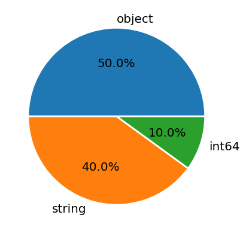

```python
# Affichage des types des variables en grapphique
pdtab.dtypes.value_counts().plot.pie(autopct='%.1f%%',wedgeprops={'linewidth': 2.0, 'edgecolor': 'white'}, textprops={'size': 'x-large'})
```

```python
# Informations sur le dataframe
pdtab.info()
```

```
<class 'pandas.core.frame.DataFrame'>
RangeIndex: 845876 entries, 0 to 845875
Data columns (total 10 columns):
 #   Column             Non-Null Count   Dtype
---  ------             --------------   -----
 0   IDCLIENT           845876 non-null  string
 1   CIVILITE           845876 non-null  string
 2   DATENAISSANCE      507902 non-null  object
 3   MAGASIN            845876 non-null  string
 4   DATEDEBUTADHESION  845876 non-null  object
 5   DATEREADHESION     507816 non-null  object
 6   DATEFINADHESION    845876 non-null  object
 7   VIP                845876 non-null  int64
 8   CODEINSEE          818455 non-null  string
 9   PAYS               845873 non-null  object
dtypes: int64(1), object(5), string(4)
memory usage: 64.5+ MB
```

**Note** : **Type de données**

- Nous observons que les variables **DATENAISSANCE**, **DATEDEBUTADHESION**, **DATEREADHESION** et **DATEFINADHESION** sont au format Objet, peut-être qu'il sera nécessaire de le convertir ces variables au format Date.
- **VIP** est de type entier (**int64**). Il sera peut-être necessaire de convertir cette variable en **Boolean** ou en **int32** et laisser 0 (pour client **NON VIP**).

**Note** : **valeurs manquantes**

- **Variables concernées** : **DATENAISSANCE**, **DATEREADHESION**, **CODEINSEE**, **PAYS**
- **DATENAISSANCE** : **507902** au lieu de **845876** ; **Nombre de valeurs manquantes** : (**845876** - **507902**) = **337974**
- **DATEREADHESION** : **507816** au lieu de **845876** ; **Nombre de valeurs manquantes** : (**845876** - **507816**) = **338060**
- **CODEINSEE** : **818455** au lieu de **845876** ; **Nombre de valeurs manquantes** : (**845876** - **818455**) = **27421**
- **PAYS** : **845873** au lieu de **845876** ; **Nombre de valeurs manquantes** : (**845876** - **845873**) = **3**

### **3.2.4- Statistique Descriptives**

#### **Affichage des premières lignes du dataframe**

```python
# Affiche les 10 premières lignes du dataframe
pdtab.head(3)
```

|  | IDCLIENT | CIVILITE | DATENAISSANCE | MAGASIN | DATEDEBUTADHESION | DATEREADHESION | DATEFINADHESION | VIP | CODEINSEE | PAYS |
| --- | --- | --- | --- | --- | --- | --- | --- | --- | --- | --- |
| 0 | 155891 | MADAME | None | VLG | 13/05/2005 0:00:00 | 4/04/2017 0:00:00 | 30/04/2018 0:00:00 | 0 | 74224 | FR |
| 1 | 156023 | MONSIEUR | 7/08/1966 0:00:00 | VLG | 14/05/2005 0:00:00 | 21/06/2014 0:00:00 | 30/06/2016 0:00:00 | 0 | 74189 | FR |
| 2 | 124203 | MADAME | None | BEA | 16/03/2005 0:00:00 | 12/10/2017 0:00:00 | 31/10/2018 0:00:00 | 0 | 63070 | FR |

#### **Statistiques Descriptives**

```python
# Satatistiques descriptives pour vérifier les valeurs manquantes (complétude).
var_pdtab = list(pdtab.columns)
st.get_stats_quali(pdtab[var_pdtab])
```

|  | dtype | nunique | min | max | taux_na |
| --- | --- | --- | --- | --- | --- |
| IDCLIENT | string | 845876 | 10000 | 99999 | 0.000000 |
| CIVILITE | string | 6 | MADAME | monsieur | 0.000000 |
| DATENAISSANCE | object | 27869.0 | NaN | NaN | 0.399555 |
| MAGASIN | string | 67 | ALB | VLG | 0.000000 |
| DATEDEBUTADHESION | object | 6356 | 1/01/1997 0:00:00 | 9/12/2017 0:00:00 | 0.000000 |
| DATEREADHESION | object | 2860.0 | NaN | NaN | 0.399657 |
| DATEFINADHESION | object | 161 | 1/01/2100 0:00:00 | 9/09/2018 0:00:00 | 0.000000 |
| VIP | int64 | 2 | 0 | 1 | 0.000000 |
| CODEINSEE | string | 16126 | () | CH6645 | 0.032417 |
| PAYS | object | 48.0 | NaN | NaN | 0.000004 |

#### **Affichage des valeurs uniques pour certaines variables catégorielles**

```python
# Affiche les valeurs uniques des variable catégorielles
for col in ['CIVILITE', 'MAGASIN', 'VIP', 'PAYS']:
    #print('colonne : ', col, ' : ', client[col].unique())
    # Trie des valeurs de la variable
    pdtab = pdtab.sort_values(by=[col])
    print(f'{col :-<50} {pdtab[col].unique()}')
```

```
CIVILITE------------------------------------------ <StringArray>
['MADAME', 'MONSIEUR', 'Mme', 'Mr', 'madame', 'monsieur']
Length: 6, dtype: string
MAGASIN------------------------------------------- <StringArray>
['ALB', 'ALM', 'AVI', 'BAR', 'BEA', 'BEC', 'BLA', 'BRE', 'BSN', 'CAG', 'CLA',
 'CLI', 'DIJ', 'DUM', 'ECU', 'EPN', 'EST', 'FEG', 'FRV', 'GAI', 'GAP', 'GEX',
 'HAG', 'HEI', 'IAB', 'LAB', 'MAC', 'MAN', 'MET', 'MOB', 'MOU', 'MUL', 'NEV',
 'OBE', 'ORL', 'PEG', 'PEP', 'POC', 'PON', 'PRI', 'QUE', 'RAV', 'RMA', 'SAL',
 'SCH', 'SEM', 'SEY', 'SGL', 'SJV', 'SLM', 'SMA', 'SMR', 'SNO', 'SSM', 'STE',
 'STR', 'SUR', 'THO', 'VAL', 'VAR', 'VEN', 'VIB', 'VIC', 'VIF', 'VIT', 'VIV',
 'VLG']
Length: 67, dtype: string
VIP----------------------------------------------- [0 1]
PAYS---------------------------------------------- ['AD' 'AE' 'AF' 'AM' 'AT' 'BE' 'BG' 'BR' 'CA' 'CH' 'DE' 'DK' 'DZ' 'ES'
 'FI' 'FR' 'GA' 'GB' 'GF' 'GM' 'GR' 'IT' 'JM' 'JP' 'LA' 'LK' 'LU' 'LV'
 'MA' 'MC' 'MQ' 'MT' 'NC' 'NL' 'NO' 'PL' 'PT' 'RO' 'RU' 'SE' 'SM' 'SZ'
 'TN' 'TR' 'UA' 'US' 'VN' 'ZA' None]
```

## **4- Identification et Traitement des valeurs (manquantes, doublons, aberrantes), Formatage des variables et Filtre sur le périmètre**

### **4.1- Affichage des valeurs manquantes - Observation de tout le jeu de données dans une image** :

- **Il existe des valeurs manquantes dans notre jeu de données**.

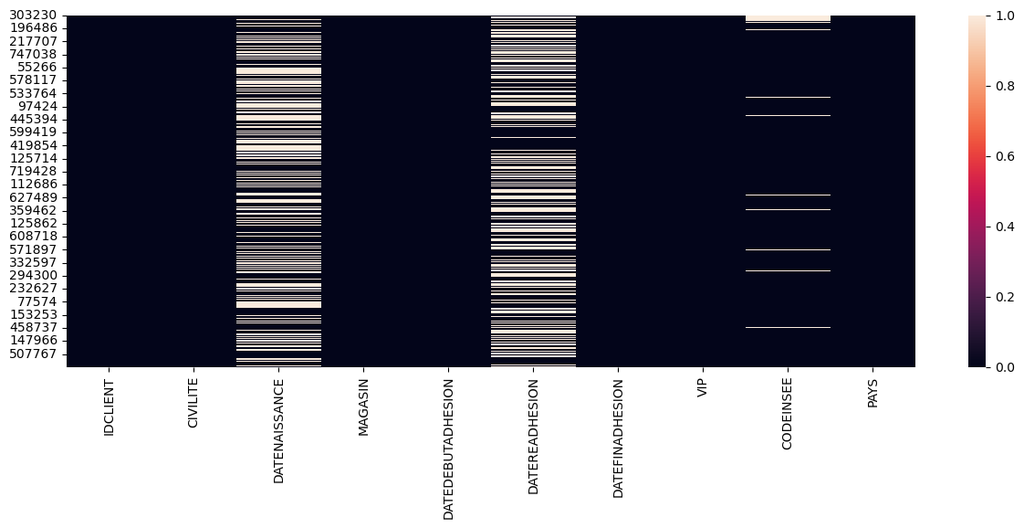

```python
plt.figure(figsize=(15,5))
sns.heatmap(pdtab.isna(), cbar=True)
```

- **Note** : **Affichage des valeurs manquantes - Observation de tout le jeu de données dans une image**
  - En noir, ce sont les positions dans lesquelles il y a des valeurs.
  - En blanc, ce sont les positions dans lesquelles il y a des valeurs manquantes.
  - Notre jeu de données a des valeurs manquantes.

### **4.2- Mesure du pourcentage des valeurs manquantes** : Il existe des valeurs manquantes dans notre jeu de données.

```python
# Afficher le pourcentage des valeurs manquantes
(pdtab.isna().sum()/pdtab.shape[0]).sort_values(ascending=True)
```

```
IDCLIENT             0.000000
CIVILITE             0.000000
MAGASIN              0.000000
DATEDEBUTADHESION    0.000000
DATEFINADHESION      0.000000
VIP                  0.000000
PAYS                 0.000004
CODEINSEE            0.032417
DATENAISSANCE        0.399555
DATEREADHESION       0.399657
dtype: float64
```

**Note** :

### **4.3- Traitement des valeurs manquantes**

#### **4.3.1- Traitement des valeurs de la variable** DATENAISSANCE** qui permet de définir l'âge du client**

- - def age(born)

```python
# Calcul de l'age
pdtab['Age'] = pdtab['DATENAISSANCE'].apply(age)
pdtab.head()
```

|  | IDCLIENT | CIVILITE | DATENAISSANCE | MAGASIN | DATEDEBUTADHESION | DATEREADHESION | DATEFINADHESION | VIP | CODEINSEE | PAYS | Age |
| --- | --- | --- | --- | --- | --- | --- | --- | --- | --- | --- | --- |
| 303230 | 2506166 | MONSIEUR | 21/02/1958 0:00:00 | BLA | 25/10/2013 0:00:00 | 21/06/2016 0:00:00 | 30/06/2017 0:00:00 | 0 | <NA> | AD | 58 |
| 152202 | 1819176 | MONSIEUR | None | PEP | 15/05/2010 0:00:00 | 25/10/2015 0:00:00 | 31/10/2016 0:00:00 | 0 | <NA> | AD | 0 |
| 251000 | 1953242 | MADAME | None | LAB | 28/03/2011 0:00:00 | 9/02/2016 0:00:00 | 28/02/2018 0:00:00 | 1 | <NA> | AD | 0 |
| 608970 | 3180712 | MONSIEUR | 5/03/1963 0:00:00 | AVI | 17/07/2016 0:00:00 | None | 31/07/2017 0:00:00 | 0 | <NA> | AE | 53 |
| 625110 | 3261510 | MADAME | 19/03/1973 0:00:00 | MOU | 31/01/2017 0:00:00 | None | 31/01/2018 0:00:00 | 0 | <NA> | AF | 43 |

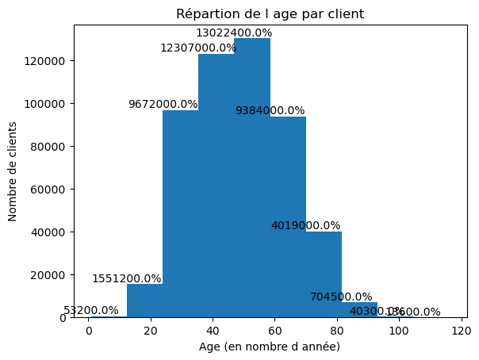

```python
filtered_client = pdtab[pdtab['Age'] > 0]
Scatter_Plot(filtered_client,'Age', 'Nombre de clients','Age (en nombre d année)','Répartion de l age par client')
```

**Note** : D'après ce graphique il y'a 4 reparations :

- 1- Les 'sans age'
- 2- inferieur à 40 ans
- 3- de 40 ans à 60 ans
- 4- supérieur à 60 ans

##### **4.3.1.1- Mise en place d'une Variable categorielle pour les tranches d'âge**

```python
# Definir une variable categorielle pour les tranches d'age
rules = {
        (-100, 17): "1_Sans age",
        (18, 40): "2_inferieur a 40",
        (41, 60): "3_Entre 40 et 60",
        (60, 200): "5_Plus de 60 ans"
}
pdtab['TrancheAge'] =pd.cut(pdtab["Age"], bins=[r[0] for r in rules.keys()] + [200], labels=[rules[r] for r in rules.keys()])
```

```python
percentTrancheAge = PourcentageModalites(pdtab,'TrancheAge')
percentTrancheAge
```

```
1_Sans age          40.2%
3_Entre 40 et 60    24.8%
2_inferieur a 40    20.6%
5_Plus de 60 ans    14.5%
Name: TrancheAge, dtype: object
```

##### **4.3.1.2- Statistiques descriptives**

- - variable : Age

```python
var_quanti = ['Age']
st.get_stats_quanti(pdtab[var_quanti])
```

|  | dtype | min | max | mean | std | median | taux_na | taux_var |
| --- | --- | --- | --- | --- | --- | --- | --- | --- |
| Age | int64 | 0.0 | 116.0 | 29.247936 | 26.635593 | 33.0 | 0.0 | 0.910683 |

#### **4.3.2- Traitement des valeurs manquantes de la variable DATEREADHESION**

Nous allons créer deux variables pour distinguer 3 types de clients : client nouveau, client ancien avec réadhesion, client ancien sans réadhesion.

```python
pdtab['readhesion'] = pdtab['DATEREADHESION'].apply(readhesion)
pdtab.head()
```

|  | IDCLIENT | CIVILITE | DATENAISSANCE | MAGASIN | DATEDEBUTADHESION | DATEREADHESION | DATEFINADHESION | VIP | CODEINSEE | PAYS | Age | TrancheAge | readhesion |
| --- | --- | --- | --- | --- | --- | --- | --- | --- | --- | --- | --- | --- | --- |
| 303230 | 2506166 | MONSIEUR | 21/02/1958 0:00:00 | BLA | 25/10/2013 0:00:00 | 21/06/2016 0:00:00 | 30/06/2017 0:00:00 | 0 | <NA> | AD | 58 | 3_Entre 40 et 60 | readherent |
| 152202 | 1819176 | MONSIEUR | None | PEP | 15/05/2010 0:00:00 | 25/10/2015 0:00:00 | 31/10/2016 0:00:00 | 0 | <NA> | AD | 0 | 1_Sans age | readherent |
| 251000 | 1953242 | MADAME | None | LAB | 28/03/2011 0:00:00 | 9/02/2016 0:00:00 | 28/02/2018 0:00:00 | 1 | <NA> | AD | 0 | 1_Sans age | readherent |
| 608970 | 3180712 | MONSIEUR | 5/03/1963 0:00:00 | AVI | 17/07/2016 0:00:00 | None | 31/07/2017 0:00:00 | 0 | <NA> | AE | 53 | 3_Entre 40 et 60 | non readherent |
| 625110 | 3261510 | MADAME | 19/03/1973 0:00:00 | MOU | 31/01/2017 0:00:00 | None | 31/01/2018 0:00:00 | 0 | <NA> | AF | 43 | 3_Entre 40 et 60 | non readherent |

#### **4.3.3- Traitement des valeurs manquantes de la variable DUREEADHESION**

```python
pdtab['DureeAdhesion'] = pdtab.apply(DureeAdhesion, axis=1)
pdtab.head()
```

|  | IDCLIENT | CIVILITE | DATENAISSANCE | MAGASIN | DATEDEBUTADHESION | DATEREADHESION | DATEFINADHESION | VIP | CODEINSEE | PAYS | Age | TrancheAge | readhesion | DureeAdhesion |
| --- | --- | --- | --- | --- | --- | --- | --- | --- | --- | --- | --- | --- | --- | --- |
| 303230 | 2506166 | MONSIEUR | 21/02/1958 0:00:00 | BLA | 25/10/2013 0:00:00 | 21/06/2016 0:00:00 | 30/06/2017 0:00:00 | 0 | <NA> | AD | 58 | 3_Entre 40 et 60 | readherent | 38 |
| 152202 | 1819176 | MONSIEUR | None | PEP | 15/05/2010 0:00:00 | 25/10/2015 0:00:00 | 31/10/2016 0:00:00 | 0 | <NA> | AD | 0 | 1_Sans age | readherent | 79 |
| 251000 | 1953242 | MADAME | None | LAB | 28/03/2011 0:00:00 | 9/02/2016 0:00:00 | 28/02/2018 0:00:00 | 1 | <NA> | AD | 0 | 1_Sans age | readherent | 69 |
| 608970 | 3180712 | MONSIEUR | 5/03/1963 0:00:00 | AVI | 17/07/2016 0:00:00 | None | 31/07/2017 0:00:00 | 0 | <NA> | AE | 53 | 3_Entre 40 et 60 | non readherent | 5 |
| 625110 | 3261510 | MADAME | 19/03/1973 0:00:00 | MOU | 31/01/2017 0:00:00 | None | 31/01/2018 0:00:00 | 0 | <NA> | AF | 43 | 3_Entre 40 et 60 | non readherent | 0 |

#### **4.3.4- Histogramme - Distribution des modalités de la variable readhesion**

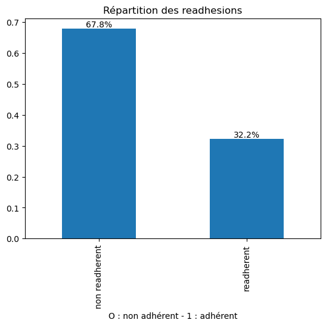

```python
# Repartition des valeurs de la variable adherent2017
frequences = pdtab['readhesion'].value_counts(normalize=True, dropna=False)
frequences.plot(kind='bar')
plt.xlabel('O : non adhérent - 1 : adhérent')
plt.ylabel('')
plt.title('Répartition des readhesions')
for i, freq in enumerate(frequences):
    if pd.isnull(frequences.index[i]):
        label = 'NaN'
    else:
        label = frequences.index[i]
    plt.text(i, freq, f'{freq*100:.1f}%', ha='center', va='bottom')
plt.show()
```

#### **4.3.5- Traitement des valeurs manquantes de la variable PAYS**

- Supression des pays sauf la france.

```python
# Supprimer les lignes avec la valeur differente de  'FR' dans la colonne 'PAYS'
pdtab = pdtab[~(pdtab['PAYS'] != 'FR')]

# Réindexer le DataFrame après suppression
pdtab = pdtab.reset_index(drop=True)
pdtab.head(10)
```

|  | IDCLIENT | CIVILITE | DATENAISSANCE | MAGASIN | DATEDEBUTADHESION | DATEREADHESION | DATEFINADHESION | VIP | CODEINSEE | PAYS | Age | TrancheAge | readhesion | DureeAdhesion |
| --- | --- | --- | --- | --- | --- | --- | --- | --- | --- | --- | --- | --- | --- | --- |
| 0 | 3266196 | MONSIEUR | None | BSN | 14/02/2017 0:00:00 | None | 28/02/2018 0:00:00 | 0 | 77445 | FR | 0 | 1_Sans age | non readherent | 0 |
| 1 | 3514587 | MONSIEUR | 3/09/2001 0:00:00 | BEA | 24/12/2017 0:00:00 | None | 31/12/2018 0:00:00 | 0 | 06118 | FR | 15 | 1_Sans age | non readherent | 0 |
| 2 | 2716201 | MADAME | 4/10/1963 0:00:00 | BSN | 11/07/2014 0:00:00 | 6/05/2017 0:00:00 | 31/05/2018 0:00:00 | 0 | 77067 | FR | 53 | 3_Entre 40 et 60 | non readherent | 29 |
| 3 | 2947065 | MONSIEUR | None | BSN | 6/09/2015 0:00:00 | None | 30/09/2016 0:00:00 | 0 | 91114 | FR | 0 | 1_Sans age | non readherent | 15 |
| 4 | 3214965 | MADAME | None | BSN | 15/10/2016 0:00:00 | None | 31/10/2017 0:00:00 | 0 | 51492 | FR | 0 | 1_Sans age | non readherent | 2 |
| 5 | 2319371 | MADAME | None | BEA | 10/04/2013 0:00:00 | 30/04/2017 0:00:00 | 30/04/2018 0:00:00 | 0 | 63075 | FR | 0 | 1_Sans age | non readherent | 44 |
| 6 | 3131805 | MADAME | None | BSN | 7/06/2016 0:00:00 | None | 30/06/2017 0:00:00 | 0 | 77487 | FR | 0 | 1_Sans age | non readherent | 6 |
| 7 | 2899839 | MONSIEUR | None | BSN | 16/05/2015 0:00:00 | 1/04/2017 0:00:00 | 30/04/2018 0:00:00 | 0 | 77454 | FR | 0 | 1_Sans age | non readherent | 19 |
| 8 | 3425358 | MADAME | 22/01/1973 0:00:00 | BEA | 15/07/2017 0:00:00 | None | 31/07/2018 0:00:00 | 0 | 63307 | FR | 43 | 3_Entre 40 et 60 | non readherent | 0 |
| 9 | 112393 | MADAME | None | BEA | 15/05/2005 0:00:00 | 22/11/2017 0:00:00 | 30/11/2018 0:00:00 | 0 | 63075 | FR | 0 | 1_Sans age | non readherent | 139 |

#### **4.3.6- Traitement des valeurs manquantes de la variable CODEINSEE**

- **Codeinsee** : Seul 3% du jeu de données manquant. ces 3% ne sont pas significatifs, nous supprimerons ces enregistrements.
- On complétera avec les données du magasin.

```python
# Supprimer les lignes avec la valeur est None dans la colonne 'CODEINSEE'
pdtab = pdtab[~pdtab['CODEINSEE'].isna()]
# Réindexer le DataFrame après suppression
pdtab = pdtab.reset_index(drop=True)
pdtab.head(10)
```

|  | IDCLIENT | CIVILITE | DATENAISSANCE | MAGASIN | DATEDEBUTADHESION | DATEREADHESION | DATEFINADHESION | VIP | CODEINSEE | PAYS | Age | TrancheAge | readhesion | DureeAdhesion |
| --- | --- | --- | --- | --- | --- | --- | --- | --- | --- | --- | --- | --- | --- | --- |
| 0 | 3266196 | MONSIEUR | None | BSN | 14/02/2017 0:00:00 | None | 28/02/2018 0:00:00 | 0 | 77445 | FR | 0 | 1_Sans age | non readherent | 0 |
| 1 | 3514587 | MONSIEUR | 3/09/2001 0:00:00 | BEA | 24/12/2017 0:00:00 | None | 31/12/2018 0:00:00 | 0 | 06118 | FR | 15 | 1_Sans age | non readherent | 0 |
| 2 | 2716201 | MADAME | 4/10/1963 0:00:00 | BSN | 11/07/2014 0:00:00 | 6/05/2017 0:00:00 | 31/05/2018 0:00:00 | 0 | 77067 | FR | 53 | 3_Entre 40 et 60 | non readherent | 29 |
| 3 | 2947065 | MONSIEUR | None | BSN | 6/09/2015 0:00:00 | None | 30/09/2016 0:00:00 | 0 | 91114 | FR | 0 | 1_Sans age | non readherent | 15 |
| 4 | 3214965 | MADAME | None | BSN | 15/10/2016 0:00:00 | None | 31/10/2017 0:00:00 | 0 | 51492 | FR | 0 | 1_Sans age | non readherent | 2 |
| 5 | 2319371 | MADAME | None | BEA | 10/04/2013 0:00:00 | 30/04/2017 0:00:00 | 30/04/2018 0:00:00 | 0 | 63075 | FR | 0 | 1_Sans age | non readherent | 44 |
| 6 | 3131805 | MADAME | None | BSN | 7/06/2016 0:00:00 | None | 30/06/2017 0:00:00 | 0 | 77487 | FR | 0 | 1_Sans age | non readherent | 6 |
| 7 | 2899839 | MONSIEUR | None | BSN | 16/05/2015 0:00:00 | 1/04/2017 0:00:00 | 30/04/2018 0:00:00 | 0 | 77454 | FR | 0 | 1_Sans age | non readherent | 19 |
| 8 | 3425358 | MADAME | 22/01/1973 0:00:00 | BEA | 15/07/2017 0:00:00 | None | 31/07/2018 0:00:00 | 0 | 63307 | FR | 43 | 3_Entre 40 et 60 | non readherent | 0 |
| 9 | 112393 | MADAME | None | BEA | 15/05/2005 0:00:00 | 22/11/2017 0:00:00 | 30/11/2018 0:00:00 | 0 | 63075 | FR | 0 | 1_Sans age | non readherent | 139 |